# Análisis de Relación Entre Variables Asignadas

Juan Fernando Patiño Castro

22/3/2021

- Fuerza de Trabajo
- Características y Composición del Hogar
- Educación
- Datos de la Vivienda

De la base de datos asignada “Atención integral de los niños y niñas menores de 5 años” no se destacan variables puesto que todas ellas se realizan a un menor de edad.

Llamado de Librerías

```r
library(dplyr)
```

```r
library(ggplot2)
library(knitr)
```

# Obtención de Datos

## Descarga de Bases de Datos

En caso de que no exista, se crea la carpeta “Datos” en donde se alojarán las bases de datos

```r
if (!dir.exists("./Datos")) {
  dir.create("./Datos")
}
```

Se descargan las bases de datos. Se descarga el zip completo y de el se extrae únicamente el archivo csv correspondiente

```r
#Función para descargar bases de datos
descargar_bd <- function (url_origen, ruta_destino, nombre_archivo) {

  #Se descarga el archivo zip que contiene los conjuntos de datos
  download.file(url = url_origen, destfile = ruta_destino, method = "curl")

  #Se extrae el .csv que contiene los datos
  unzip(zipfile =  ruta_destino, files = nombre_archivo, exdir = "./Datos")

  #Se elimina el zip
  unlink(ruta_destino)
}
```

```r
#Almacenando las url de las bases de datos
url_Caracteristicas <- "http://microdatos.dane.gov.co/index.php/catalog/678/download/13707"
url_fuerza <- "http://microdatos.dane.gov.co/index.php/catalog/678/download/13711"
url_educacion <- "http://microdatos.dane.gov.co/index.php/catalog/678/download/13710"
url_vivienda <- "http://microdatos.dane.gov.co/index.php/catalog/678/download/13705"

#Se crean las rutas de destino del archivo
ruta_destino_caracteristicas <- "./Datos/Caracteristicas.zip"
ruta_destino_fuerza <- "./Datos/Fuerza de trabajo.zip"
ruta_destino_educacion <- "./Datos/Educacion.zip"
ruta_destino_vivienda <- "./Datos/Vivienda.zip"

#Se crea el nombre del archivo a extraer de cada zip
nombre_caracteristicas <- "Caracteristicas y composicion del hogar.csv"
nombre_trabajo <- "Fuerza de trabajo.csv"
nombre_educacion <- "Educaci¢n.csv"
nombre_vivienda <- "Datos de la vivienda.csv"

#Se descarga la base de datos usando la función creada previamente
descargar_bd(url_Caracteristicas, ruta_destino_caracteristicas, nombre_caracteristicas)
descargar_bd(url_fuerza, ruta_destino_fuerza, nombre_trabajo)
descargar_bd(url_educacion, ruta_destino_educacion, nombre_educacion)
descargar_bd(url_vivienda, ruta_destino_vivienda, nombre_vivienda)

#Borrando variables que no se usan
rm(url_Caracteristicas)
rm(url_fuerza)
rm(url_educacion)
rm(url_vivienda)
rm(ruta_destino_caracteristicas)
rm(ruta_destino_fuerza)
rm(ruta_destino_educacion)
rm(ruta_destino_vivienda)
```

## Lectura de archivos csv

```r
#Lectura de la composición del hogar
csv_caracteristicas <- read.csv2(file = paste("./Datos/", nombre_caracteristicas, sep=""), sep = ";", dec = ",")
csv_trabajo <- read.csv2(file = paste("./Datos/", nombre_trabajo, sep=""), sep = ";", dec = ",")
csv_educacion <- read.csv2(file = paste("./Datos/", nombre_educacion, sep=""), sep = ";", dec = ",")
csv_vivienda <- read.csv2(file = paste("./Datos/", nombre_vivienda, sep=""), sep = ";", dec = ",")
```

Corrigiendo el nombre de la primera columna para todos los csv y observando el resultado

```r
#Se cambia el nombre de la primera columna
colnames(csv_caracteristicas)[1] <- "Directorio"
colnames(csv_trabajo)[1] <- "Directorio"
colnames(csv_educacion)[1] <- "Directorio"
colnames(csv_vivienda)[1] <- "Directorio"
```

### Características y Composición del Hogar

```r
colnames(csv_caracteristicas)
```

```
##  [1] "Directorio"         "SECUENCIA_ENCUESTA" "SECUENCIA_P"
##  [4] "ORDEN"              "P6016"              "P1894"
##  [7] "P6020"              "P6034"              "P6040"
## [10] "P6051"              "P5502"              "P6071"
## [13] "P6071S1"            "P756"               "P756S1"
## [16] "P756S2"             "P756S3"             "P6074"
## [19] "P767"               "P6076"              "P6076S1"
## [22] "P6076S2"            "P6077"              "P6096"
## [25] "P6081"              "P6081S1"            "P6087"
## [28] "P6083"              "P6083S1"            "P6088"
## [31] "P6080"              "P5667"              "P2057"
## [34] "P2059"              "P2061"              "P1895"
## [37] "P1896"              "P1897"              "P1898"
## [40] "P1899"              "P1901"              "P1903"
## [43] "P1904"              "P1905"              "P1927"
## [46] "FEX_C"
```

### Fuerza de Trabajo

```r
colnames(csv_trabajo)
```

```
##   [1] "Directorio"         "SECUENCIA_ENCUESTA" "SECUENCIA_P"
##   [4] "ORDEN"              "P6230"              "P6240"
##   [7] "P6250"              "P6260"              "P6270"
##  [10] "P6280"              "P6300"              "P6320"
##  [13] "P6330"              "P6340"              "P6351"
##  [16] "P6370S2"            "P6390S2"            "P6435"
##  [19] "P6440"              "P6450"              "P6460"
##  [22] "P6460S1"            "P6990"              "P6426"
##  [25] "P8622"              "P8624"              "P6595"
##  [28] "P6595S1"            "P6605"              "P6605S1"
##  [31] "P6623"              "P6623S1"            "P6615"
##  [34] "P6615S1"            "P8626"              "P8626S1"
##  [37] "P8628"              "P8628S1"            "P8630"
##  [40] "P8630S1"            "P8631"              "P8631S1"
##  [43] "P1087"              "P1087S1"            "P1087S1A1"
```

[output cut: 26 more lines]

### Educación

```r
colnames(csv_educacion)
```

```
##  [1] "Directorio"         "SECUENCIA_ENCUESTA" "SECUENCIA_P"
##  [4] "ORDEN"              "P6160"              "P8586"
##  [7] "P6218"              "P8587"              "P8587S1"
## [10] "P6211"              "P5455"              "P1088"
## [13] "P1088S1"            "P6216"              "P5457"
## [16] "P5673"              "P5674"              "P6223"
## [19] "P1101"              "P5461"              "P5461S1"
## [22] "P5461S2"            "P5461S3"            "P4693"
## [25] "P6167"              "P6180"              "P6180S1"
## [28] "P6180S2"            "P1928"              "P1928S1"
## [31] "P1928S2"            "P1928S2A1"          "P8610"
## [34] "P8610S1"            "P8610S2"            "P6229"
## [37] "P8612"              "P8612S1"            "P8612S2"
## [40] "P6238"              "P8614"              "P8614S1"
## [43] "P8614S2"            "P6202"              "P781"
## [46] "P781S1"             "P781S2"             "P782"
## [49] "P783"               "P3004"              "P3004S1"
## [52] "P3004S2"            "P3004S3"            "P3004S4"
## [55] "P3004S5"            "P3004S6"            "P3004S7"
## [58] "FEX_C"
```

### Datos de la Vivienda

```r
colnames(csv_vivienda)
```

```
##  [1] "Directorio"            "SECUENCIA_ENCUESTA"    "SECUENCIA_P"
##  [4] "ORDEN"                 "REGION"                "P1_DEPARTAMENTO"
##  [7] "CANT_HOG_COMPLETOS"    "CANT_HOGARES_VIVIENDA" "CLASE"
## [10] "P1070"                 "P4005"                 "P4015"
## [13] "P4567"                 "P8520"                 "P8520S1"
## [16] "P8520S1A1"             "P8520S5"               "P8520S3"
## [19] "P8520S4"               "P8520S4A1"             "P4065"
## [22] "P4065S1"               "P4065S2"               "P4065S3"
## [25] "P4065S4"               "P5661"                 "P5661S1"
## [28] "P5661S2"               "P5661S3"               "P5661S4"
## [31] "P5661S9"               "P5661S5"               "P5661S6"
## [34] "P5661S7"               "FEX_C"
```

# Estudio de las Variables Asignadas

En este caso las variables asignadas son:

- P8634 (Fuerza Trabajo)
- P2059 (Características y Composición del Hogar)
- P5502 (Características y Composición del Hogar)
- P6218 (Educación)
- P8520S1 (Datos de la Vivienda)
- P1070 (Datos de la Vivienda)

## Preprocesamiento

Primero se encuentra el número de hijos por hogar usando la base de datos “Características y Composición del Hogar”

```r
#Se cuentan el numero de hijos por hogar
hijos_hogar <- csv_caracteristicas %>% select(Directorio, P6051) %>% filter(P6051 == 3) %>% count(Directorio)

#Se renombra la columna 2
colnames(hijos_hogar)[2] <- "Hijos"

head(hijos_hogar)
```

```
##   Directorio Hijos
## 1    7120001     1
## 2    7120002     5
## 3    7120009     1
## 4    7120010     3
## 5    7120016     2
## 6    7120018     2
```

Ahora se asignan los hijos a cada jefe de hogar

```r
#Se filtra el parentezco dejando solo a los jefes de hogar
jefe_hogar <- csv_caracteristicas %>% filter(P6051 == 1)

#Se asocian los hijos a cada jefe de hogar
hijos_jefe <- merge(jefe_hogar, hijos_hogar, by = "Directorio", all = TRUE)

#A los jefe de hogar sin hijos se les establecen cero hijos
hijos_jefe$Hijos[is.na(hijos_jefe$Hijos)] <- 0

#Se eliminan las variables no utilizadas
rm(jefe_hogar)
```

## Variable P8634 (Fuerza Trabajo)

Los encuestados responden a la siguente pregunta: **Fundamentalmente, donde realiza usted su trabajo principal:**

1. Local fijo, oficina, fabrica, etc.
2. En la vivienda que habita
3. En otras viviendas
4. En quiosco o caseta
5. En un vehículo (taxi, carro, bus, lancha, barco)
6. Puerta a puerta
7. Sitio al descubierto en la calle (ambulante o estacionario)
8. En el campo o área rural, mar, o rio
9. En una obra de construcción
10. En una mina o cantera

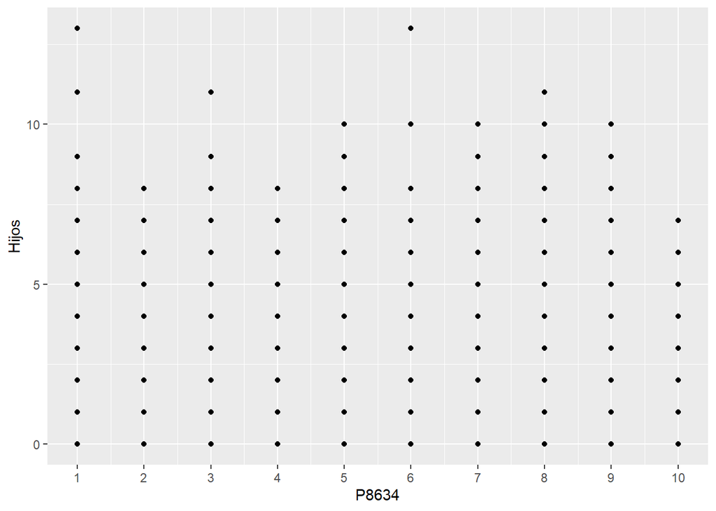

```r
auxiliar_datos <- csv_trabajo %>% filter(ORDEN == 1) %>% select(Directorio, P8634)

auxiliar_merge <- merge(hijos_jefe, csv_trabajo, by = "Directorio", all = TRUE)

ggplot(subset(auxiliar_merge, !is.na(P8634)), aes(x = P8634, y = Hijos)) + geom_point() + scale_x_continuous(breaks=c(1,2,3,4,5,6,7,8,9,10))
```

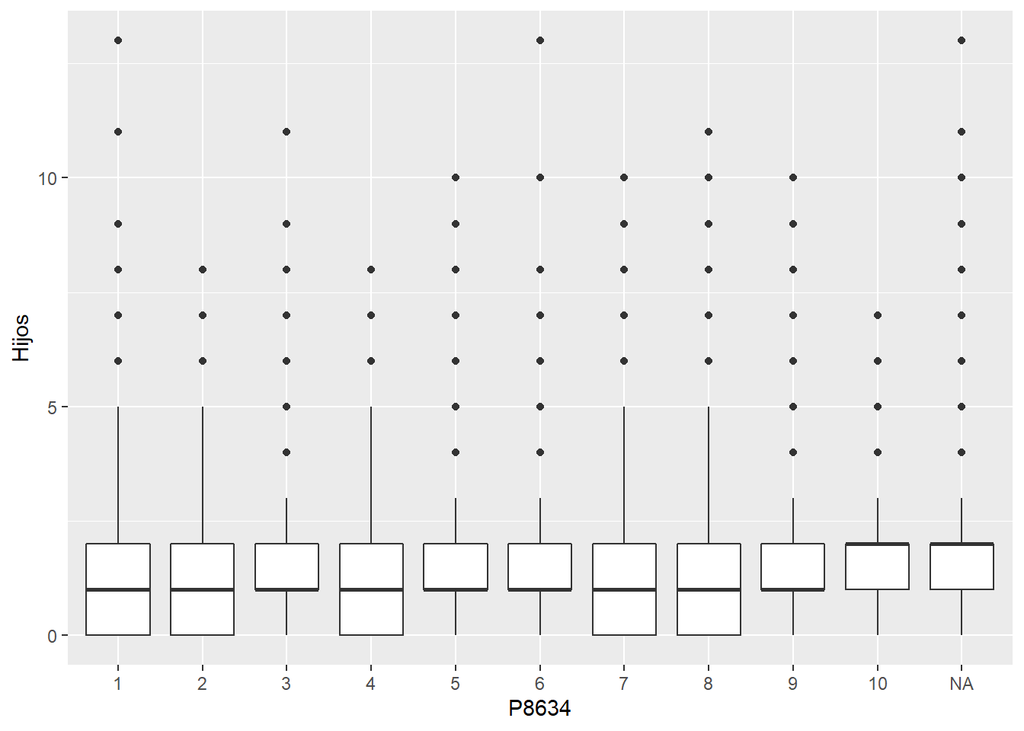

```r
ggplot(auxiliar_merge, aes(x = as.factor(P8634), y = Hijos)) +  geom_boxplot() + xlab("P8634")
```

## Variable P2059 (Características y Composición del Hogar)

Los encuestados responden a la siguente pregunta: **¿Usted considera que alguna vez fue campesino(a)?**

1. Si
2. No
3. No informa

```r
#Se hace una corrección porque aparecen N/A y en vez de 9 un 3
hijos_jefe$P2059[is.na(hijos_jefe$P2059)] <- 3
hijos_jefe$P2059[hijos_jefe$P2059 == 9] <- 3

tapply(hijos_jefe$Hijos, hijos_jefe$P2059, summary)
```

```
## $`1`
##    Min. 1st Qu.  Median    Mean 3rd Qu.    Max.
##   0.000   0.000   1.000   1.092   2.000   8.000
##
## $`2`
##    Min. 1st Qu.  Median    Mean 3rd Qu.    Max.
##   0.000   0.000   1.000   1.145   2.000  13.000
##
## $`3`
##    Min. 1st Qu.  Median    Mean 3rd Qu.    Max.
##   0.000   0.000   1.000   1.138   2.000  11.000
```

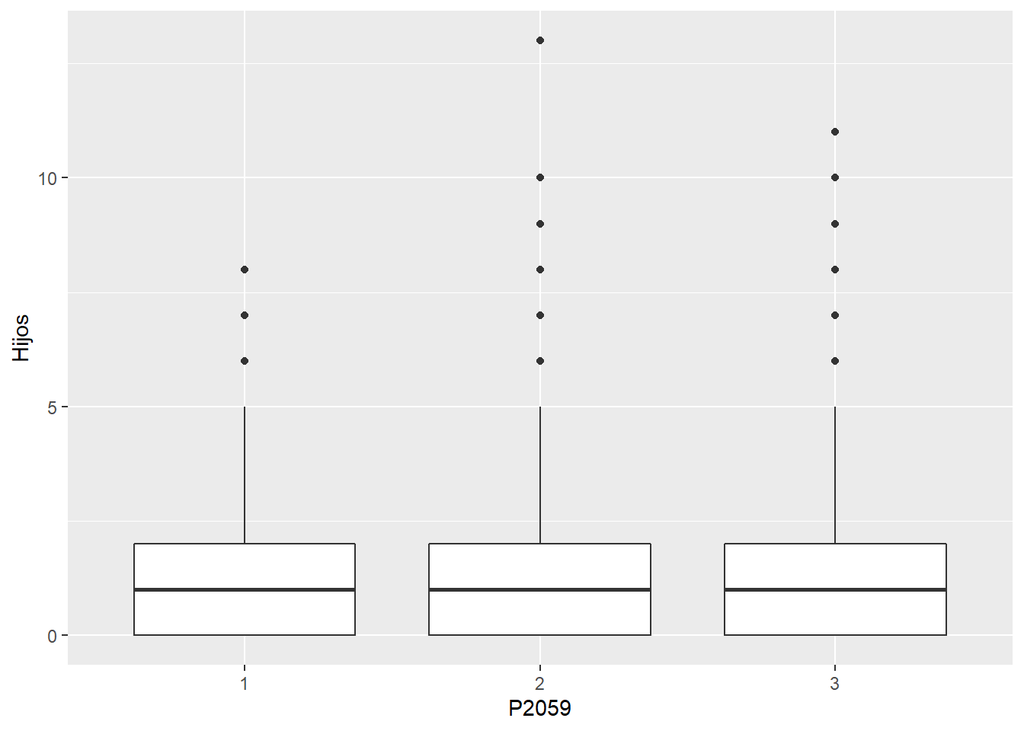

```r
ggplot(hijos_jefe, aes(x = as.factor(P2059), y = Hijos)) +  geom_boxplot() + xlab("P2059")
```

## Variable P5502 (Características y Composición del Hogar)

Los encuestados responden a la siguente pregunta: **Actualmente…**

1. No está casado(a) y vive en pareja hace menos de dos años
2. No está casado(a) y vive en pareja hace dos años o más
3. Está viudo(a)
4. Está separado(a) o divorciado(a)
5. Está soltero(a)
6. Está casado(a)

```r
tapply(hijos_jefe$Hijos, hijos_jefe$P5502, summary)
```

```
## $`1`
##    Min. 1st Qu.  Median    Mean 3rd Qu.    Max.
##  0.0000  0.0000  1.0000  0.9737  1.0000 13.0000
##
## $`2`
##    Min. 1st Qu.  Median    Mean 3rd Qu.    Max.
##   0.000   1.000   1.000   1.529   2.000  11.000
##
## $`3`
##    Min. 1st Qu.  Median    Mean 3rd Qu.    Max.
##  0.0000  0.0000  1.0000  0.7831  1.0000  8.0000
##
## $`4`
##    Min. 1st Qu.  Median    Mean 3rd Qu.    Max.
##  0.0000  0.0000  1.0000  0.9905  2.0000 13.0000
##
## $`5`
##    Min. 1st Qu.  Median    Mean 3rd Qu.    Max.
##  0.0000  0.0000  0.0000  0.4649  1.0000 10.0000
##
## $`6`
##    Min. 1st Qu.  Median    Mean 3rd Qu.    Max.
##   0.000   0.000   1.000   1.165   2.000  10.000
```

```r
table(hijos_jefe[c("Hijos", "P5502")])
```

```
##      P5502
## Hijos     1     2     3     4     5     6
##    0   1001  8154  3968  7118  8627  7756
##    1    737 10089  2473  4413  2019  6349
##    2    355  8889  1033  2902   968  5150
##    3    154  4139   338  1116   320  1811
##    4     39  1578    95   351    92   510
##    5     17   555    41   128    30   149
##    6      8   219     9    38     9    53
##    7      2    87     4     5    10    16
##    8      1    27     2     5     4     8
##    9      0     5     0     0     2     2
##    10     1     4     0     0     1     2
##    11     0     2     0     0     0     0
##    13     2     0     0     1     0     0
```

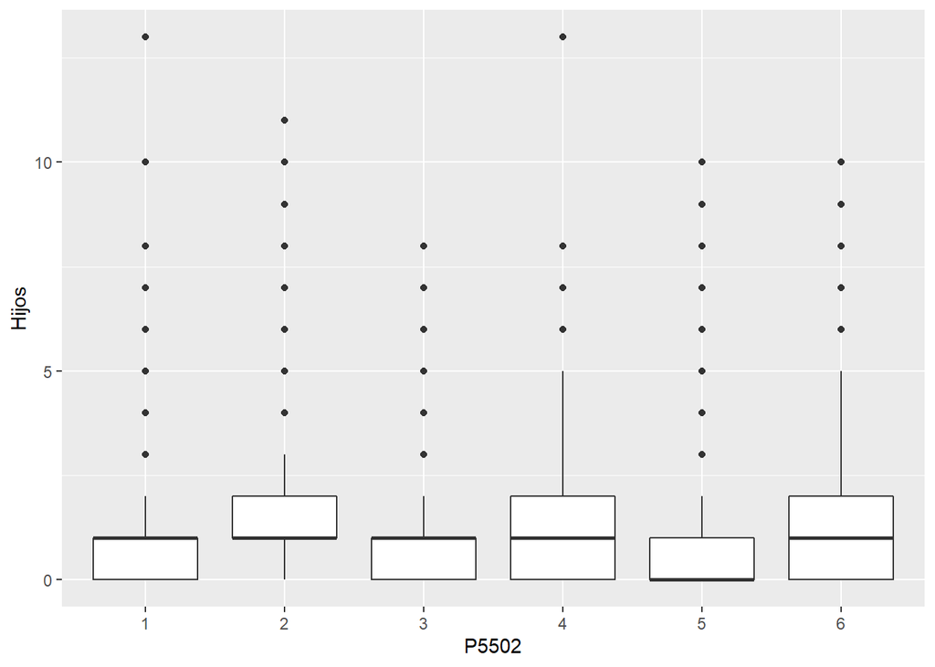

```r
ggplot(hijos_jefe, aes(x = as.factor(P5502), y = Hijos)) + geom_boxplot() + xlab("P5502")
```

## Variable P6218 (Educación)

Los encuestados responden a la siguente pregunta: **Cuál es la razón principal para qué_no estudie?**

1. Considera que no está en edad escolar
2. Considera que ya terminó
3. Falta de dinero o costos educativos elevados
4. Debe encargarse de los oficios del hogar (cuidado de niño(a)s y de otras personas del hogar:ancianos(ADULTOS MAYORES), personas discapacitadas, etc.)
5. Por embarazo
6. Por inseguridad o malos tratos en el establecimiento educativo; inseguridad en el entorno del centro educativo o del lugar de residencia
7. Falta de cupos
8. No existe centro educativo cercano o el establecimiento asignado es muy lejano
9. Necesita trabajar
10. No le gusta o no le interesa el estudio
11. Por enfermedad
12. Necesita educación especial
13. Tuvieron que abandonar el lugar de residencia habitual
14. Sus padres o la persona encargada de su cuidado no lo considera importante
15. Por situaciones académicas (bajos resultados en el periodo académico, repetición de cursos)
16. Otra razón, ¿cuál?

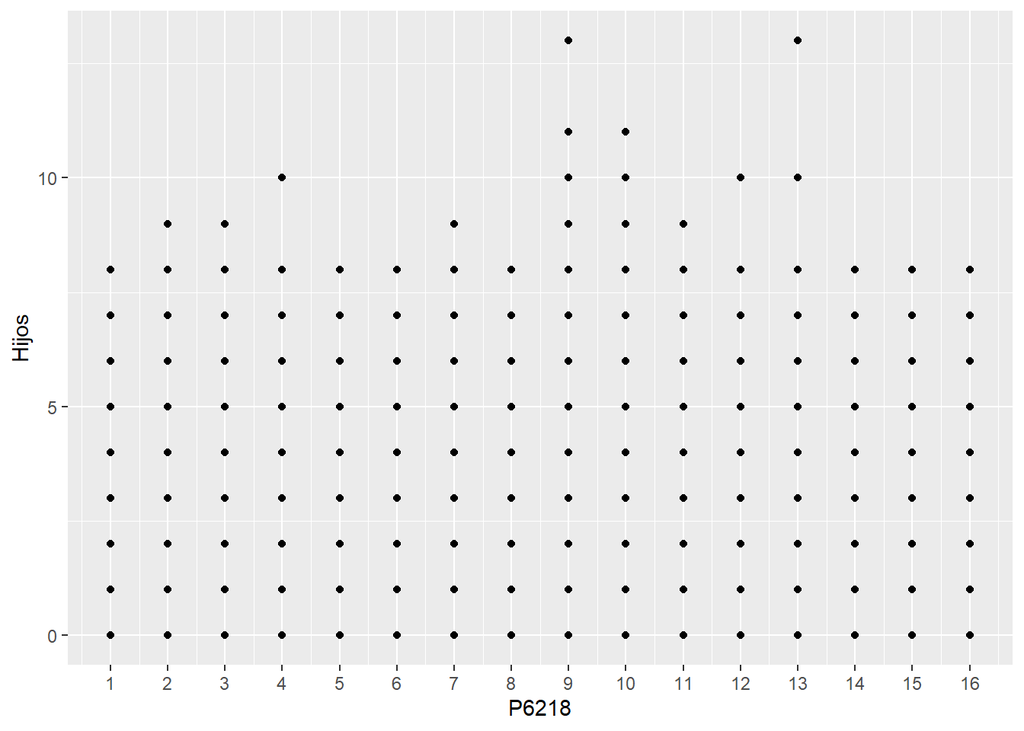

```r
auxiliar_datos <- csv_educacion %>% filter(ORDEN == 1) %>% select(Directorio, P6218)

auxiliar_merge <- merge(hijos_jefe, csv_educacion, by = "Directorio", all = TRUE)

ggplot(subset(auxiliar_merge, !is.na(P6218)), aes(x = P6218, y = Hijos)) + geom_point() + scale_x_continuous(breaks=c(1,2,3,4,5,6,7,8,9,10,11,12,13,14,15,16))
```

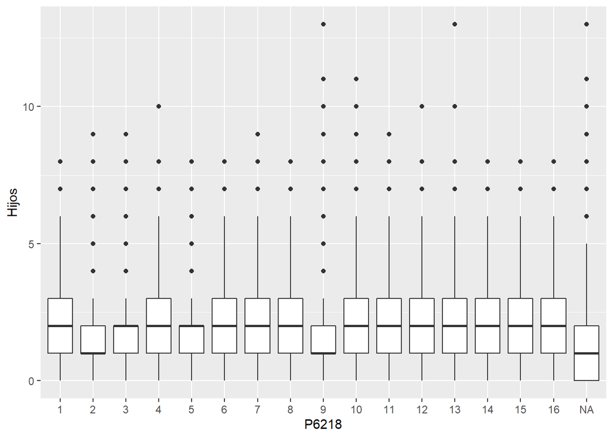

```r
ggplot(auxiliar_merge, aes(x = as.factor(P6218), y = Hijos)) +  geom_boxplot() + xlab("P6218")
```

```r
#hijos_jefe %>% select(Hijos, P415) %>% filter(!is.na(P415)) %>% cor()
```

## Variable P8520S1 (Datos de la Vivienda)

Los encuestados responden a la siguente pregunta: **¿Con cuáles de los siguientes servicios públicos, privados o comunales cuenta la vivienda? 1. Energía eléctrica**

1. Sí
2. No

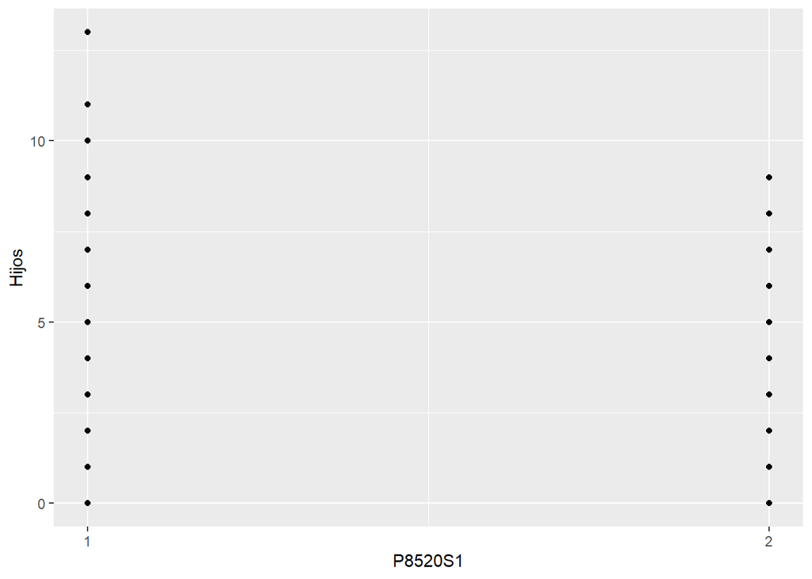

```r
auxiliar_datos <- csv_vivienda %>% filter(ORDEN == 1) %>% select(Directorio, P8520S1)

auxiliar_merge <- merge(hijos_jefe, csv_vivienda, by = "Directorio", all = TRUE)

ggplot(subset(auxiliar_merge, !is.na(P8520S1)), aes(x = P8520S1, y = Hijos)) + geom_point() + scale_x_continuous(breaks=c(1,2))
```

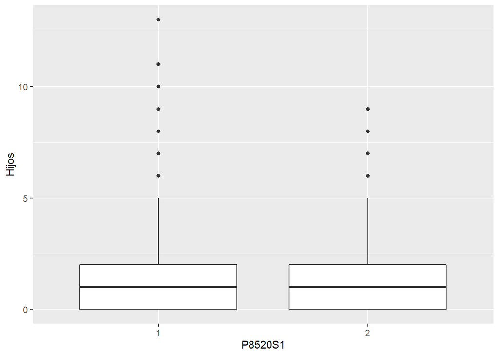

```r
ggplot(auxiliar_merge, aes(x = as.factor(P8520S1), y = Hijos)) +  geom_boxplot() + xlab("P8520S1")
```

## Variable P1070 (Datos de la Vivienda)

Los encuestados responden a la siguente pregunta: **Tipo de vivienda**

1. Casa
2. Apartamento
3. Cuarto(s)
4. Vivienda tradicional indigena
5. Otro (carpa, contenedor, vagón, embarcación, cueva, refugio natural, etc)

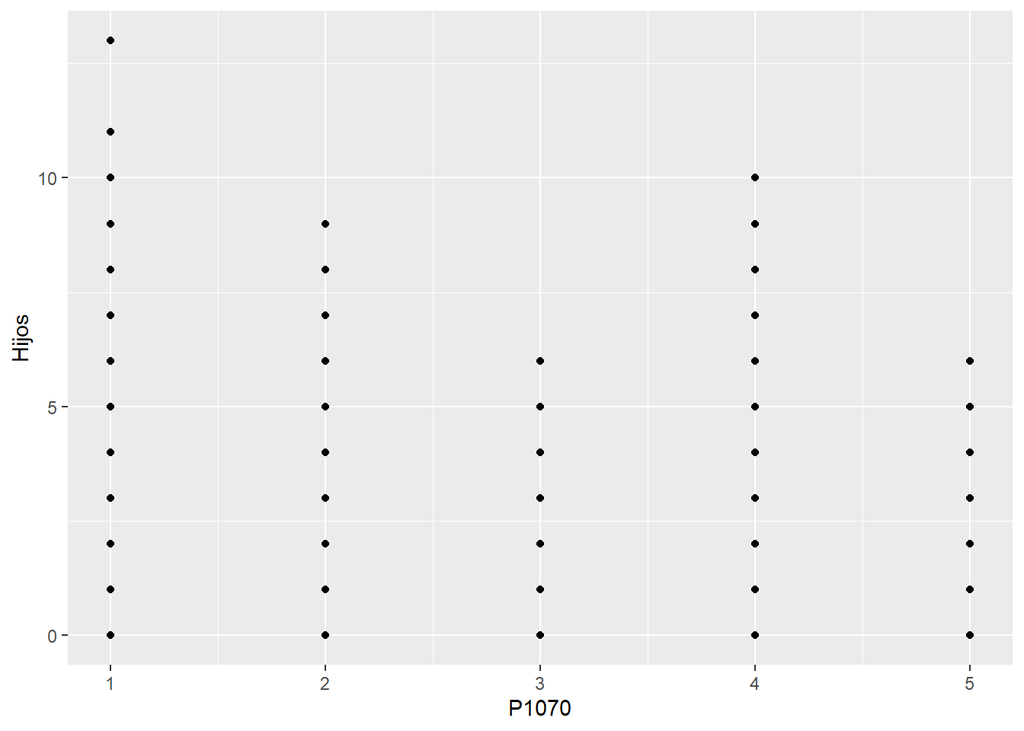

```r
#auxiliar_datos <- csv_vivienda %>% filter(ORDEN == 1) %>% select(Directorio, P8520S1)

#auxiliar_merge <- merge(hijos_jefe, csv_vivienda, by = "Directorio", all = TRUE)

ggplot(subset(auxiliar_merge, !is.na(P1070)), aes(x = P1070, y = Hijos)) + geom_point() + scale_x_continuous(breaks=c(1,2,3,4,5))
```

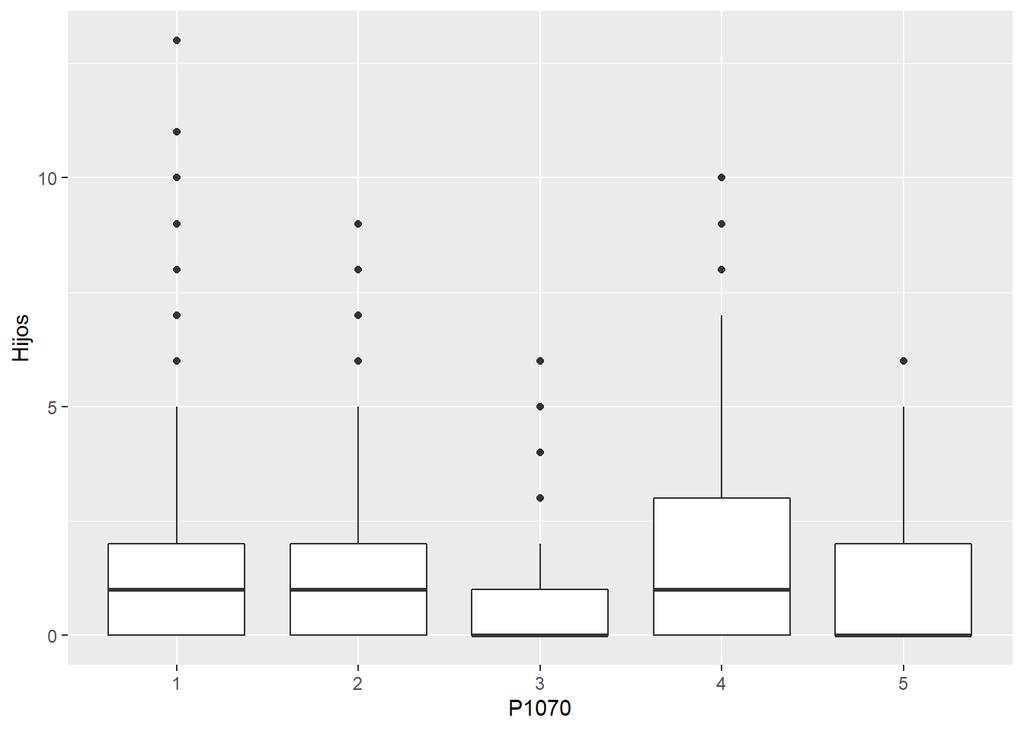

```r
ggplot(auxiliar_merge, aes(x = as.factor(P1070), y = Hijos)) +  geom_boxplot() + xlab("P1070")
```